# heat_map_for_visualization_emotions_correlation_in_COVID-19_pandemic

Yujie Ma-200256708

2021/5/9

## Introduction

COVID-19 pandemic has rapidly spread across the world and has negatively affected every aspect of human beings, including people’s physical health, economic uncertainty, mental health, and so on. Carstensen and her group have investigated the influence of age differences on the frequency and intensity of 29 emotions (16 positives and 13 negatives) during the pandemic on a sample of 945 Americans. They also used Future Time Perspective (FTP) scale to measure the time horizons to understand people’s cognitive-oriented emotional experience. As a result, they found that greater emotional well-being could be affected by age for these people from 18 to 76 years. However, limited social contact and economic uncertainty are essential sources of persistent stress for people. Although they have already considered these factors, I selected those who do not have any job to observe the relationship between 5 dimensions of different emotions. Specifically, the correlation between the frequency of positive and negative emotions, the intensity of positive and negative emotions, and the time horizons.

## Method

Pearson product-moment correlation coefficient

## Results

```r
# renv::equip() function will download external software commonly used when compiling R packages from sources,
# and instruct R to use that software during compilation
# renv::equip()

install.packages("tidyverse",repos = "https://cloud.r-project.org/")
install.packages("ggplot2",repos = "https://cloud.r-project.org/")
install.packages("RColorBrewer",repos = "https://cloud.r-project.org/")
install.packages("reshape2",repos = "https://cloud.r-project.org/")
install.packages("here",repos = "https://cloud.r-project.org/")
# to help create output files in gif or movie file format
install.packages("gifski",repos = "https://cloud.r-project.org/")
install.packages("av",repos = "https://cloud.r-project.org/")
# this package is for dynamic graph
install.packages("gganimate",repos = "https://cloud.r-project.org/")
# to save the state of the project library to the lockfile
# renv::snapshot()


# loading the library after you have installed them
library(tidyverse)
library(ggplot2)
library(RColorBrewer)
library(reshape2)
# this package is for dynamic graph
library(gganimate)
library(here)
# loading the data in the csv file into R
df <- read.csv(here("data","AgeAdvantagesEmotionCovid_Data.csv"))

# data wrangling
# using filter to select the people who do not have jobs at present and choose 5 columns including FTP_av, avg_f_pos, avg_f_neg, avg_i_pos and avg_i_neg
not_working_df <- df %>%
  filter(emp_bin=="Not_working")
not_working_df <- not_working_df %>%
  select(FTP_av,avg_f_pos,avg_f_neg,avg_i_pos,avg_i_neg)

# renaming the columns to show the exact meaning
colnames(not_working_df)<-
  c("time horizons",
    "positive emotions frequency",
    "negtive emotions frequency",
    "positive emotions intensity",
    "negtive emotions intensity")

# using head to inspect not_working_df
head(not_working_df)
```

```
##   time horizons positive emotions frequency negtive emotions frequency
## 1           4.6                    1.812500                  1.3333333
## 2           4.2                    1.454545                  2.3076923
## 3           6.2                    2.437500                  1.0000000
## 4           6.6                    2.187500                  1.6666667
## 5           3.8                    1.461538                  2.1818182
## 6           5.2                    2.437500                  0.9230769
##   positive emotions intensity negtive emotions intensity
## 1                    2.250000                   2.333333
## 2                    1.153846                   2.363636
## 3                    1.812500                   1.625000
## 4                    2.133333                   2.166667
## 5                    1.062500                   1.846154
## 6                    2.375000                   1.625000
```

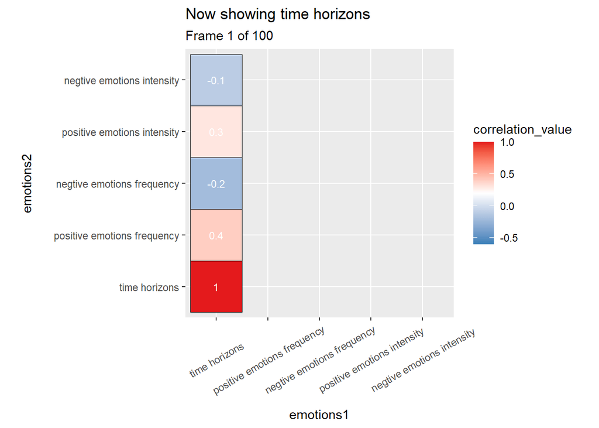

```r
# plotting dynamic heat map chart
# computing the correlation between these 5 columns and rounding the values in its first argument to the specified number of decimal places
# and converting the dataset to a list form
mat_df <- round(cor(not_working_df), 1)
mydata_df <- melt(mat_df)
# renaming the mydata_df columns
colnames(mydata_df)<-c("emotions1","emotions2","correlation_value")
#showing mydata_df as a correlation graph
p <- ggplot(mydata_df, aes(x = emotions1, y = emotions2, fill = correlation_value,label=correlation_value)) +
  theme(axis.text.x = element_text(angle = 30, hjust = 0.5, vjust = 0.5)) +
  geom_tile(colour="black") +
  geom_text(size=3,colour="white")+
  coord_equal()+
  scale_fill_gradientn(colours=c(brewer.pal(7,"Set1")[2],"white",brewer.pal(7,"Set1")[1]),na.value=NA)

# making the correlation map into a dynamic graph
anim <- p +
  transition_states(emotions1,
                    transition_length = 2,
                    state_length = 1)+
  shadow_mark()+
  enter_grow()+ enter_fade()+
  ease_aes('cubic-in-out')  +
  ggtitle('Now showing {closest_state}',
          subtitle = 'Frame {frame} of {nframes}')

# displaying
anim
```

```r
# saving this figure.
anim_save(filename = "../image/emotions_correlation_heat_map.gif")
```

According to the graph, we can see that a high positive correlation between the frequency and intensity of positive emotions is anticipated as before, r = 0.8. A positive correlation (r = 0.7) between the frequency and intensity of negative emotions is also what I expected. The correlations between positive and negative emotions from these two dimensions are Moderate and negative, with r = -0.6 and r = -0.5 separately. The correlations between time horizons positive emotions from those two dimensions are a surprise, and they are weak correlations with r = 0.3 and r = 0.4 independently. The negative correlations (r = -0.1 or r = -0.2) found between time horizons and negative emotions are no or very weak.

## Discussion

The result is the same as expected. These results are in line with the “positivity effect” in Socioemotional selectivity theory, which claims the cognitive supporting emotionally meaningful goals showed by time horizons may contribute to improved emotional experience. However, the selected people in my visualization are only unemployed. It is believed that people who do not have a job will have a more apparent emotional effect because of social problems. Furthermore, the state of the economy can be another critical factor affecting the emotional state. For example, some people don’t work because of retirement, and some people are unemployed because they lose their jobs during the epidemic. Therefore, the emotional scores of people may be different. Thus, the relevant economic variables should be taken into account in later work. In addition, race, gender, age, personality, and so on are also important factors when we want more in-depth research. Apart from that, I also think that appropriate statistical methods will significantly impact a scientific result when these factors above are involved. So the result of my work is charming but needs further discussion in the future.

## References

Carstensen, Laura L, Shavit, Yochai Z, & Barnes, Jessica T. (2020). Age Advantages in Emotional Experience Persist Even Under Threat From the COVID-19 Pandemic. Psychological Science, 31(11), 1374–1385. https://doi.org/10.1177/0956797620967261

Carstensen, L.L, Turan, B, Scheibe, S, Ram, N, Ersner-Hershfield, H, Samanez-Larkin, G.R, Brooks, K.P, & Nesselroade, J.R. (2011). Emotional experience improves with age: Evidence based on over 10 years of experience sampling. Psychology and Aging, 26(1), 21–33. https://doi.org/10.1037/a0021285